# Color palette with ggplot and RColorBrewer

Leo Lu

2016-09-10

本範例需要的套件

```r
library(magrittr)
library(dplyr)
library(ggplot2)
library(RColorBrewer)
```

## 玩玩顏色

```r
library(ggplot2)
library(RColorBrewer)

data(mpg)
mpg
```

```
#> # A tibble: 234 × 11
#>    manufacturer      model displ  year   cyl      trans   drv   cty   hwy
#>           <chr>      <chr> <dbl> <int> <int>      <chr> <chr> <int> <int>
#> 1          audi         a4   1.8  1999     4   auto(l5)     f    18    29
#> 2          audi         a4   1.8  1999     4 manual(m5)     f    21    29
#> 3          audi         a4   2.0  2008     4 manual(m6)     f    20    31
#> 4          audi         a4   2.0  2008     4   auto(av)     f    21    30
#> 5          audi         a4   2.8  1999     6   auto(l5)     f    16    26
#> 6          audi         a4   2.8  1999     6 manual(m5)     f    18    26
#> 7          audi         a4   3.1  2008     6   auto(av)     f    18    27
#> 8          audi a4 quattro   1.8  1999     4 manual(m5)     4    18    26
#> 9          audi a4 quattro   1.8  1999     4   auto(l5)     4    16    25
#> 10         audi a4 quattro   2.0  2008     4 manual(m6)     4    20    28
#> # ... with 224 more rows, and 2 more variables: fl <chr>, class <chr>
```

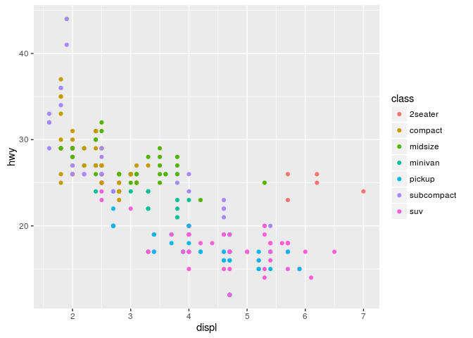

```r
p <- ggplot(mpg, aes(x = displ, y = hwy, color = class)) +
  geom_point()
plot(p)
```

我們可以很簡單地用 `scale_color_brewer()` 調整(離散型變數)的填滿顏色

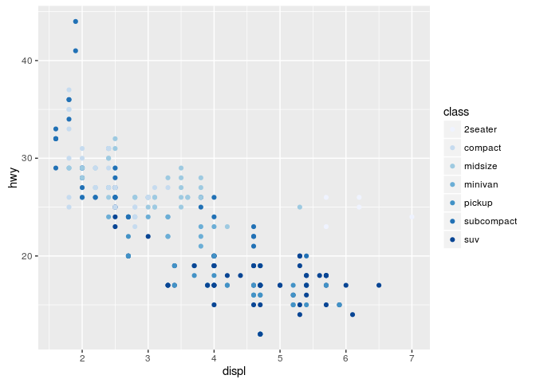

```r
p + scale_color_brewer() # default color scheme
```

## Types of palettes

看看有那些(離散變數)色彩主題可挑選

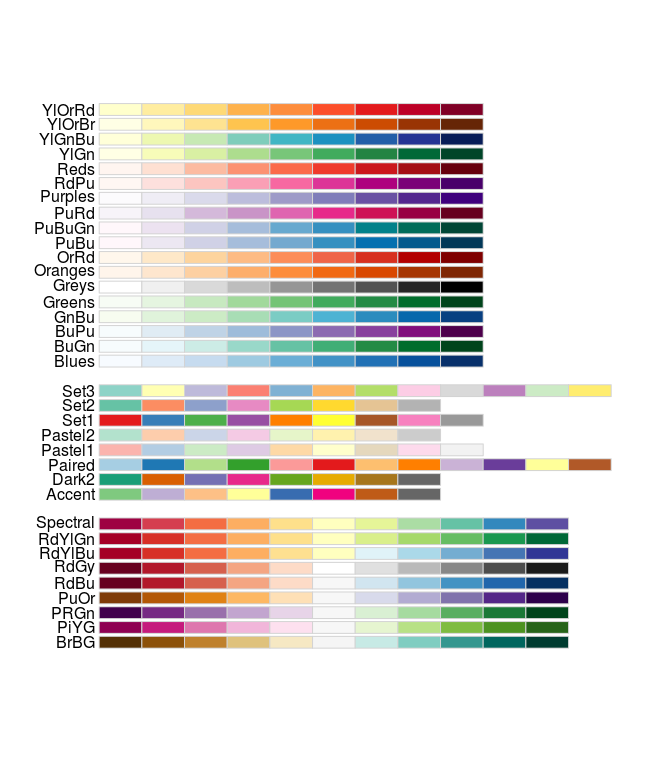

```r
library(RColorBrewer)
display.brewer.all()
```

- Diverging

BrBG, PiYG, PRGn, PuOr, RdBu, RdGy, RdYlBu, RdYlGn, Spectral

- Qualitative

Accent, Dark2, Paired, Pastel1, Pastel2, Set1, Set2, Set3

- Sequential

Blues, BuGn, BuPu, GnBu, Greens, Greys, Oranges, OrRd, PuBu, PuBuGn, PuRd, Purples, RdPu, Reds, YlGn, YlGnBu, YlOrBr, YlOrRd

換成不同顏色主題試試 `scale_color_brewer palette`:

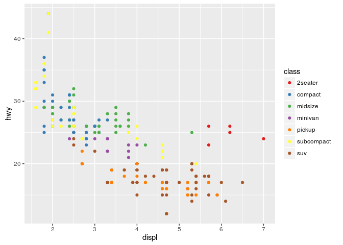

```r
p + scale_color_brewer(palette="Set1")
```

## 顏色不夠怎麼辦

```
#> Warning in RColorBrewer::brewer.pal(n, pal): n too large, allowed maximum for palette Set2 is 8
#> Returning the palette you asked for with that many colors
```

```
#> Warning in RColorBrewer::brewer.pal(n, pal): n too large, allowed maximum for palette Set2 is 8
#> Returning the palette you asked for with that many colors
```

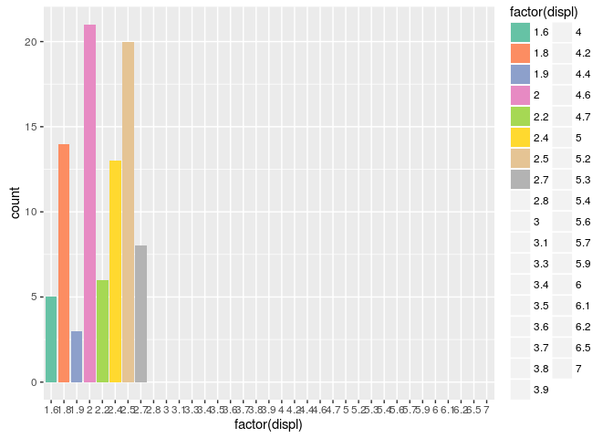

```r
p2 <- ggplot(mpg) +
  geom_bar(aes(x = factor(displ), fill = factor(displ)))
p2 + scale_fill_brewer(palette="Set2")
```

[output not shown]

## Produce larger palettes: Use `colorRamp {grDevices}`

```r
colour_count = length(unique(mpg$displ))
getPalette = colorRampPalette(brewer.pal(9, "Set1"))
getPalette
```

```
#> function (n)
#> {
#>     x <- ramp(seq.int(0, 1, length.out = n))
#>     if (ncol(x) == 4L)
#>         rgb(x[, 1L], x[, 2L], x[, 3L], x[, 4L], maxColorValue = 255)
#>     else rgb(x[, 1L], x[, 2L], x[, 3L], maxColorValue = 255)
#> }
#> <bytecode: 0x3e50e88>
#> <environment: 0x3e4f7b8>
```

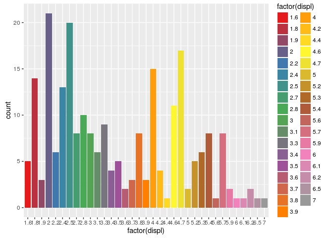

```r
p2 +
  scale_fill_manual(values = getPalette(colour_count)) +
  theme(legend.position="right")
```

## Legend problem

Another likely problem with large number of bars in histogram plots is placing of the legend. Adjust legend position and layout using theme and guides functions as follows :

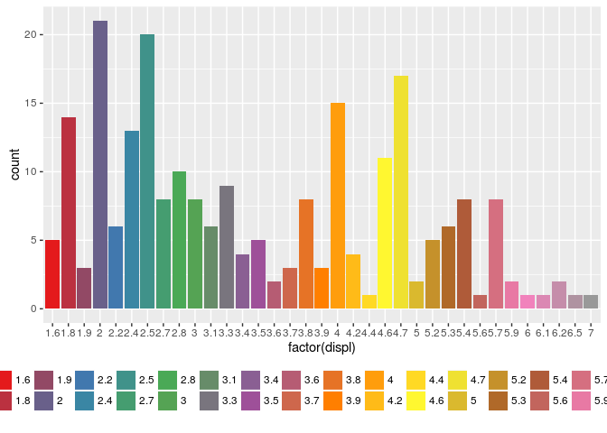

```r
p2 +
  scale_fill_manual(values = getPalette(colour_count)) +
  theme(legend.position = "bottom") +
  guides(fill = guide_legend(nrow=2))
```

Finally, the same example using in place palette constructor with different choice of library palette:

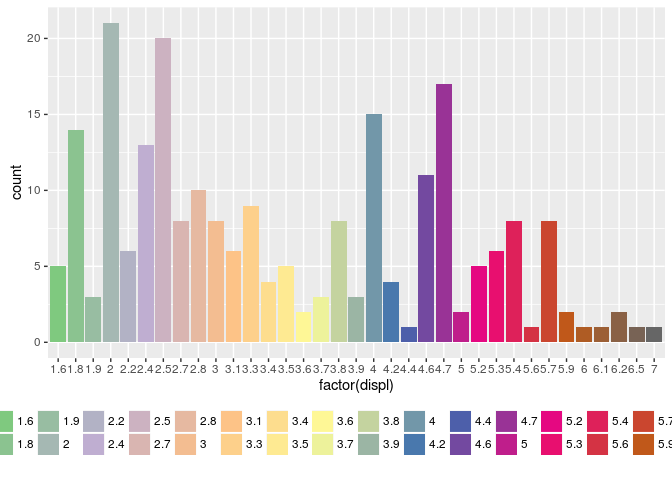

```r
p2 +
  scale_fill_manual(values = colorRampPalette(brewer.pal(12, "Accent"))(colour_count)) +
  theme(legend.position="bottom") +
  guides(fill=guide_legend(nrow=2))
```

There are many more [scale functions](http://docs.ggplot2.org/current/scale_brewer.html) to choose from depending on aesthetics type (`colour`, `fill`), color types (`gradient`, `hue`, etc.), data values (`discrete` or `continuous`).

## Refernce

- http://novyden.blogspot.tw/2013/09/how-to-expand-color-palette-with-ggplot.html